# gdp and internet

pv

17 september 2016

We start with setting the work directory and load a library to import the data. Data are from Worldbank showing sub sahara african countries on gdp per cap and internet access per 100 from 2001 to 2014.

```r
setwd("C:/Users/hp/Desktop/R/inet_gdp")
library("gdata", lib.loc="~/R/win-library/3.3")
```

Now let’s load the data:

```r
gi<-read.xls("gi.xls")
```

Let’s have alook at the data

```r
dim(gi)
```

```
## [1] 154   4
```

```r
str(gi)
```

```
## 'data.frame':    154 obs. of  4 variables:
##  $ country  : Factor w/ 11 levels "Botswana","Ghana",..: 1 1 1 1 1 1 1 1 1 1 ...
##  $ year     : int  2001 2002 2003 2004 2005 2006 2007 2008 2009 2010 ...
##  $ gdppercap: num  3115 3044 4149 4879 5328 ...
##  $ inetperc : num  3.43 3.39 3.35 3.3 3.26 ...
```

dim shows the dimensions: 4 variables over 154 data rows str shows the variable names and the level of measurement

```r
summary(gi)
```

```
##      country        year        gdppercap         inetperc
##  Botswana:14   Min.   :2001   Min.   : 149.4   Min.   : 0.0899
##  Ghana   :14   1st Qu.:2004   1st Qu.: 446.7   1st Qu.: 2.2950
##  Kenya   :14   Median :2008   Median : 930.5   Median : 5.4925
##  Malawi  :14   Mean   :2008   Mean   :1962.4   Mean   : 8.8989
##  Namibia :14   3rd Qu.:2011   3rd Qu.:2919.8   3rd Qu.:11.5000
##  Nigeria :14   Max.   :2014   Max.   :8081.4   Max.   :49.0000
##  (Other) :70
```

summary gives the basics statistics of the variables

Let’s first have a look at 2014

```r
gi2014<-subset(gi,year>2013)
gi2014$year<-NULL
head(gi2014)
```

```
##     country gdppercap inetperc
## 14 Botswana 7153.4443    18.50
## 28    Ghana 1441.6365    18.90
## 42    Kenya 1368.4911    43.40
## 56   Malawi  362.2475     5.83
## 70  Namibia 5342.9445    14.84
## 84  Nigeria 3203.2443    42.68
```

## First a **bar** plot for internet access

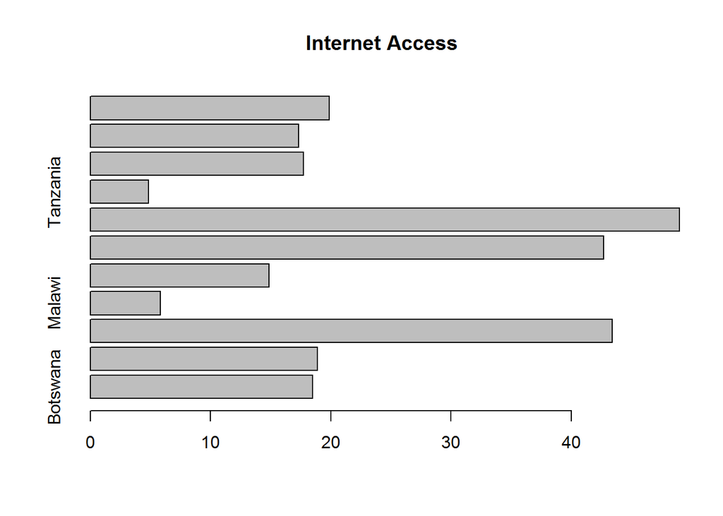

```r
x<-barplot(gi2014$inetperc, main="Internet Access", horiz=TRUE,names.arg=gi2014$country)
```

Now the plot for **GDP per cap**

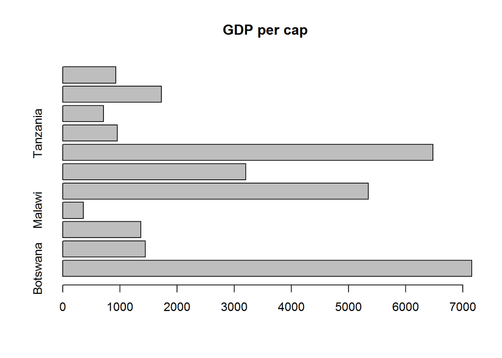

```r
barplot(gi2014$gdppercap, main="GDP per cap", horiz=TRUE,names.arg=gi2014$country)
```

and now the relationship between the variables

```r
cor(gi2014$inetperc, gi2014$gdppercap)
```

```
## [1] 0.3688982
```

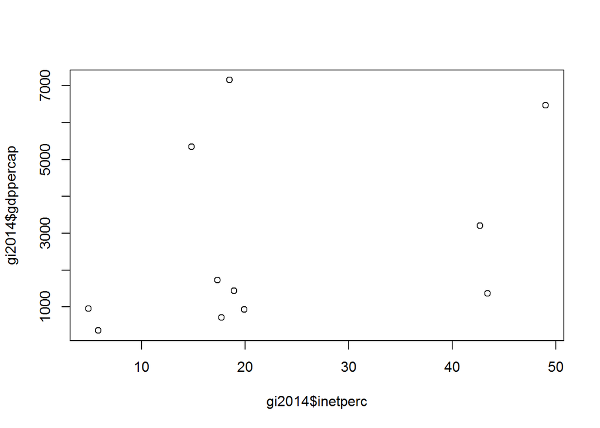

```r
plot(gi2014$inetperc, gi2014$gdppercap)
```

So we find a correlation between internet access and gdp per capita.But one can ask is this a coincidence. So let’s test the likehood of this outcome.

```r
cor.test(gi2014$gdppercap,gi2014$inetperc)
```

```
##
##  Pearson's product-moment correlation
##
## data:  gi2014$gdppercap and gi2014$inetperc
## t = 1.1907, df = 9, p-value = 0.2642
## alternative hypothesis: true correlation is not equal to 0
## 95 percent confidence interval:
##  -0.2966158  0.7932358
## sample estimates:
##       cor
## 0.3688982
```

If we test: H0: there is no relationship between internet and gdp H1: there is a relationship With p=0,2642 which is much higher than 0.05 we can not reject H0. If H0 is true then the chance to find this outcome is 26%.

And finally the **lineair model**

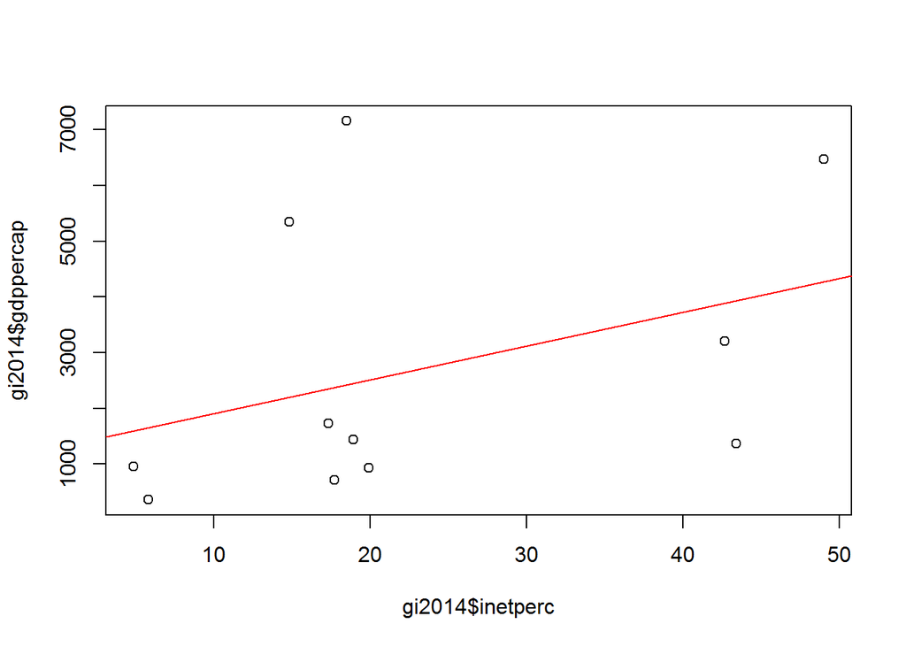

```r
plot(gi2014$inetperc, gi2014$gdppercap)
fit <-lm(gi2014$gdppercap~gi2014$inetperc)
abline(fit, col="red")
```

If you look at the plot, the values are far of the line. A linear model is used to do prediction. Predict gdp per cap on basis of internet access. In our case the prediction will be poor.  
We will try to predict the gdp per cap on basis of intenet access. In lineair model(lm) this shown by the regression line: y=ax + b. Determine the coefficients (a en b) and line shows prediction: outcome for gdp on basis of internet access. dependant variable= gdppercap=DV independant variable= inetaccess=IV

```r
gi2014.lm<-lm(gdppercap~inetperc,data=gi2014)
summary(gi2014.lm)
```

```
##
## Call:
## lm(formula = gdppercap ~ inetperc, data = gi2014)
##
## Residuals:
##     Min      1Q  Median      3Q     Max
## -2562.8 -1437.6  -684.5   786.4  4728.0
##
## Coefficients:
##             Estimate Std. Error t value Pr(>|t|)
## (Intercept)  1306.63    1377.73   0.948    0.368
## inetperc       60.48      50.79   1.191    0.264
##
## Residual standard error: 2424 on 9 degrees of freedom
## Multiple R-squared:  0.1361, Adjusted R-squared:  0.0401
## F-statistic: 1.418 on 1 and 9 DF,  p-value: 0.2642
```

```r
names(gi2014.lm)
```

```
##  [1] "coefficients"  "residuals"     "effects"       "rank"
##  [5] "fitted.values" "assign"        "qr"            "df.residual"
##  [9] "xlevels"       "call"          "terms"         "model"
```

```r
gi2014$gdppercap.lm<-gi2014.lm$fitted.values
head(gi2014)
```

```
##     country gdppercap inetperc gdppercap.lm
## 14 Botswana 7153.4443    18.50     2425.445
## 28    Ghana 1441.6365    18.90     2449.636
## 42    Kenya 1368.4911    43.40     3931.314
## 56   Malawi  362.2475     5.83     1659.206
## 70  Namibia 5342.9445    14.84     2204.101
## 84  Nigeria 3203.2443    42.68     3887.771
```

As you can see there are hughe difference between the prediction(fitted values) and the actual values. This could also be concluded from the plot and line; and also from the correlation test. we can also show this in graph were the predicted values of the gdp are red and observed/real values are blue.

```r
library(yarrr)
```

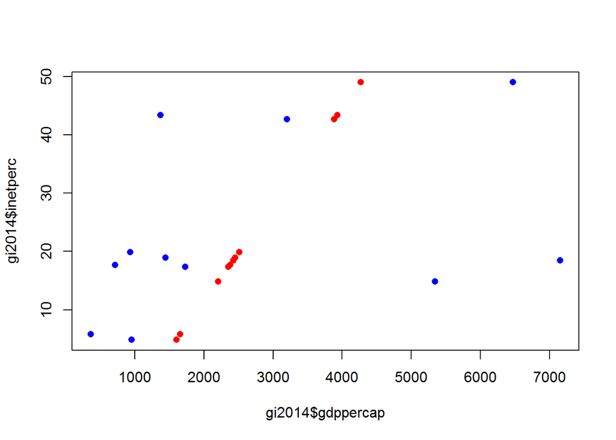

```r
plot(x=gi2014$gdppercap,y=gi2014$inetperc, pch=16, col= "blue")
points(x=gi2014$gdppercap.lm, y=gi2014$inetperc, pch=16, col="red")
```

## NOw let’s make use of Google charts and use Google charts with R

Load the library first and make a **column** chart

```r
library("googleVis", lib.loc="~/R/win-library/3.3")
```

```r
Column <- gvisColumnChart(gi2014, xvar="country", yvar="inetperc")
```

plot(Column) gives a webpage with the chart. And here is the pic

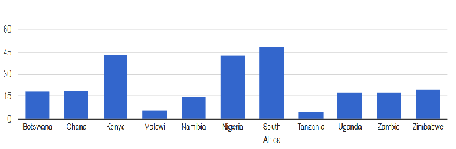

Here is a **bubble** chart

```r
Bubble <- gvisBubbleChart(gi2014, idvar="country",
                          xvar="gdppercap", yvar="inetperc",
                          colorvar="country", sizevar="inetperc")
```

plot(Bubble) gives a webpage with the chart. And here is the pic

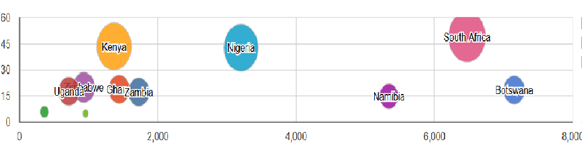

A **map** is also possible.

```r
Geo=gvisGeoChart(gi2014, locationvar="country", colorvar="inetperc")
```

plot(Geo) gives a webpage with the chart. And here is the pic

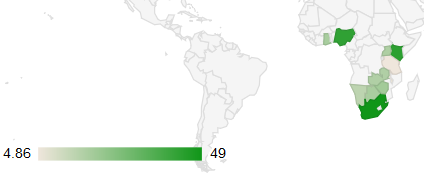

## Finally we do a **motion chart** using the complete dataset gi.xls

```r
Motion=gvisMotionChart(gi, idvar="country",timevar="year")
```

plot(Motion) will give the webpage. Here is the link to the page: [d3-media blog](http://d3-media.blogspot.nl/2016/09/integrating-google-charts-with-r.html)